# Decision Tree 4장 발표자료

Sangyeol_lee

Tuesday, April 29, 2015

### **제4장 의사결정나무**

- 의사결정나무는 분류나무(classification trees)와 회귀나무(regression trees) 모형이 있다.
- 의사결정나무는 지도학습 기법으로 각 변수의 영역을 반복적으로 분할함으로써 전체 영역에서의 규칙을 생성한다.
- 예측력은 다른 지도학습 기법들에 비해 대체로 떨어지나 해석력이 좋고 if-then 형식으로 표현되어 이해하기 쉽고
- SQL과 같은 데이터베이스 언어로 쉽게 구현되는 장점이 있다.

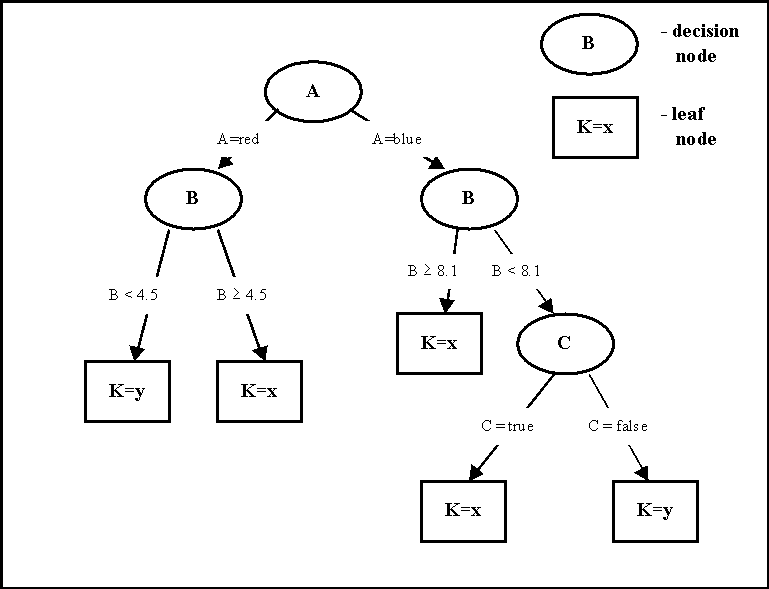

#### **구성요소**

> - 뿌리 마디(root node)
> - 자식 마디(child node)
> - 부모 마디(parent node)
> - 끝 마디(terminal node)
> - 중간 마디(internal node)
> - 가지(branch)
> - 깊이(depth)

#### **질문점**

> 1. 첫 번째 기준점을 어떻게 정할것인가?
> 2. 분할에 대한 정치규칙은 어떻게 정할것인가?
> 3. 끝마디에서의 예측값 할당은 어떻게 할것인가?

#### **제 2절 의사결정나무의 형성**

의사결정나무의 형성과정은 크게 1) 성장(growing), 2) 가지치기(pruning), 3)타당성 평가, 4)해석 및 예측

성장과정 : 각 마디에서 적절한 최적의 분리 규칙 가지치기 : 오차를 크게 할 위험이 높거나 부적절한 추론규칙을 가지고 있는 가지 또는 불필요한 가지 제거 타당성 평가 : 이익도표(gain chart), 위험도표(risk chart) 혹은 시험자료를 이용하여 의사결정나무 평가 해석 및 예측 : 구축된 나무모형 해석 예측모형 설정

##### & 이익 도표(Gain Chart) 특정 클래스에 관심이 있을 경우 상대적으로 적은 수의 데이터를 선택해 원하는 클래스 케이스를 얻음.

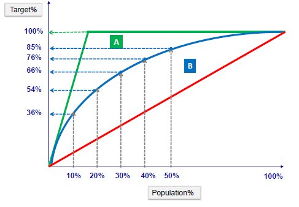

### **회귀나무(regression tree)**

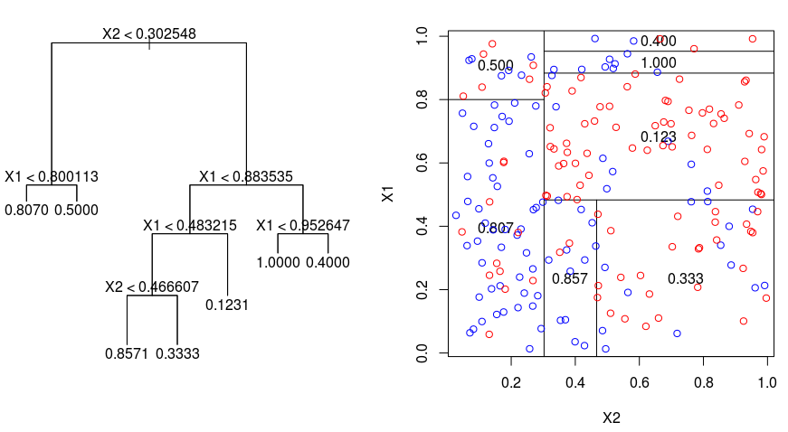

$\Delta i(t) = i(t) - p_L i(t_L) - p_R i(t_R).$ 단, $i(t)=\sum_{i \in t}(y_i - \bar y_t)^2$

```r
# Regression Tree Example
library(rpart)

 # grow tree : Mileage 미국 연료 소비 마일(US gallon), Reliability(levels), Type(a factor with levels Compact Large Medium Small Sporty Van)
head(cu.summary)
```

```
##                 Price Country Reliability Mileage  Type
## Acura Integra 4 11950   Japan Much better      NA Small
## Dodge Colt 4     6851   Japan        <NA>      NA Small
## Dodge Omni 4     6995     USA  Much worse      NA Small
## Eagle Summit 4   8895     USA      better      33 Small
## Ford Escort   4  7402     USA       worse      33 Small
## Ford Festiva 4   6319   Korea      better      37 Small
```

```r
colSums(!is.na(cu.summary))
```

```
##       Price     Country Reliability     Mileage        Type
##         117         117          85          60         117
```

```r
fit <- rpart(Mileage~Price + Country + Reliability + Type,
   method="anova", data=cu.summary)

printcp(fit) # display the results cp는 cost-complexity tunning parameter, xerror는 cross-validation error
```

```
##
## Regression tree:
## rpart(formula = Mileage ~ Price + Country + Reliability + Type,
##     data = cu.summary, method = "anova")
##
## Variables actually used in tree construction:
## [1] Price Type
##
## Root node error: 1354.6/60 = 22.576
##
## n=60 (57 observations deleted due to missingness)
##
##         CP nsplit rel error  xerror     xstd
## 1 0.622885      0   1.00000 1.03978 0.176278
## 2 0.132061      1   0.37711 0.52737 0.101869
## 3 0.025441      2   0.24505 0.36699 0.080915
## 4 0.011604      3   0.21961 0.36816 0.081741
## 5 0.010000      4   0.20801 0.38538 0.080856
```

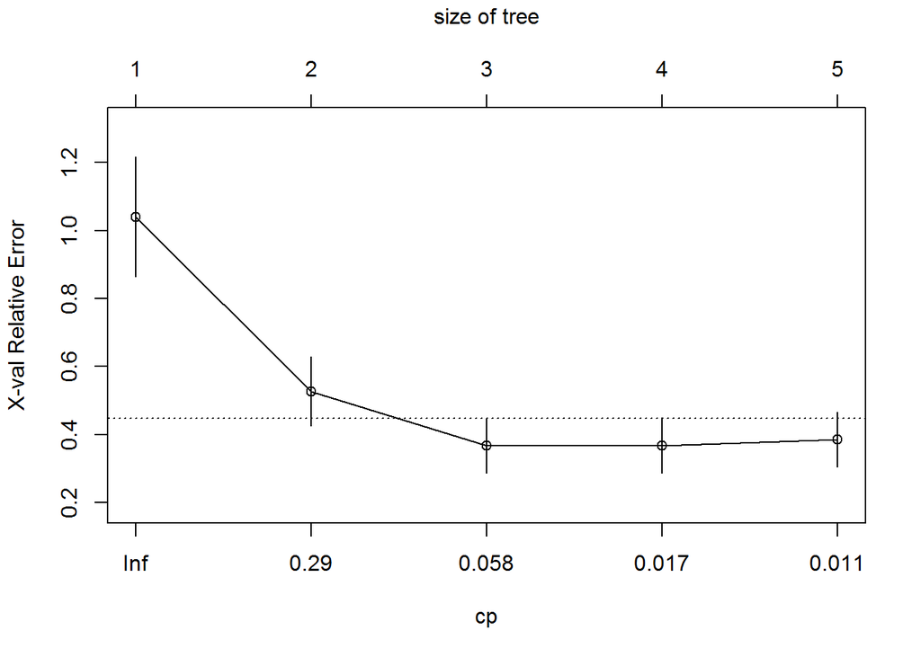

```r
plotcp(fit) # visualize cross-validation results
```

```r
summary(fit) # detailed summary of splits
```

```
## Call:
## rpart(formula = Mileage ~ Price + Country + Reliability + Type,
##     data = cu.summary, method = "anova")
##   n=60 (57 observations deleted due to missingness)
##
##           CP nsplit rel error    xerror       xstd
## 1 0.62288527      0 1.0000000 1.0397849 0.17627810
## 2 0.13206061      1 0.3771147 0.5273744 0.10186887
## 3 0.02544094      2 0.2450541 0.3669905 0.08091520
## 4 0.01160389      3 0.2196132 0.3681617 0.08174120
## 5 0.01000000      4 0.2080093 0.3853807 0.08085606
##
## Variable importance
##   Price    Type Country
##      48      42      10
##
## Node number 1: 60 observations,    complexity param=0.6228853
##   mean=24.58333, MSE=22.57639
##   left son=2 (48 obs) right son=3 (12 obs)
##   Primary splits:
##       Price       < 9446.5  to the right, improve=0.6228853, (0 missing)
##       Type        splits as  LLLRLL,      improve=0.5044405, (0 missing)
##       Reliability splits as  LLLRR,       improve=0.1263005, (11 missing)
##       Country     splits as  --LRLRRRLL,  improve=0.1243525, (0 missing)
##   Surrogate splits:
##       Type    splits as  LLLRLL,     agree=0.950, adj=0.750, (0 split)
##       Country splits as  --LLLLRRLL, agree=0.833, adj=0.167, (0 split)
##
## Node number 2: 48 observations,    complexity param=0.1320606
##   mean=22.70833, MSE=8.498264
##   left son=4 (23 obs) right son=5 (25 obs)
##   Primary splits:
##       Type        splits as  RLLRRL,      improve=0.43853830, (0 missing)
##       Price       < 12154.5 to the right, improve=0.25748500, (0 missing)
##       Country     splits as  --RRLRL-LL,  improve=0.13345700, (0 missing)
##       Reliability splits as  LLLRR,       improve=0.01637086, (10 missing)
##   Surrogate splits:
##       Price   < 12215.5 to the right, agree=0.812, adj=0.609, (0 split)
##       Country splits as  --RRLRL-RL,  agree=0.646, adj=0.261, (0 split)
##
```

[output cut: 21 more lines]

```
##   Surrogate splits:
##       Country splits as  --LLLL--LR, agree=0.80, adj=0.545, (0 split)
##       Type    splits as  L--RL-,     agree=0.64, adj=0.182, (0 split)
##
## Node number 8: 10 observations
##   mean=19.3, MSE=2.21
##
## Node number 9: 13 observations
##   mean=21.76923, MSE=0.7928994
##
## Node number 10: 14 observations
##   mean=23.85714, MSE=7.693878
##
## Node number 11: 11 observations
##   mean=25.45455, MSE=3.520661
```

```
##
## Regression tree:
## rpart(formula = Mileage ~ Price + Country + Reliability + Type,
##     data = cu.summary, method = "anova")
##
## Variables actually used in tree construction:
## [1] Price Type
##
## Root node error: 1354.6/60 = 22.576
##
## n=60 (57 observations deleted due to missingness)
##
##         CP nsplit rel error  xerror     xstd
## 1 0.622885      0   1.00000 1.03978 0.176278
## 2 0.132061      1   0.37711 0.52737 0.101869
## 3 0.025441      2   0.24505 0.36699 0.080915
## 4 0.011604      3   0.21961 0.36816 0.081741
## 5 0.010000      4   0.20801 0.38538 0.080856
```

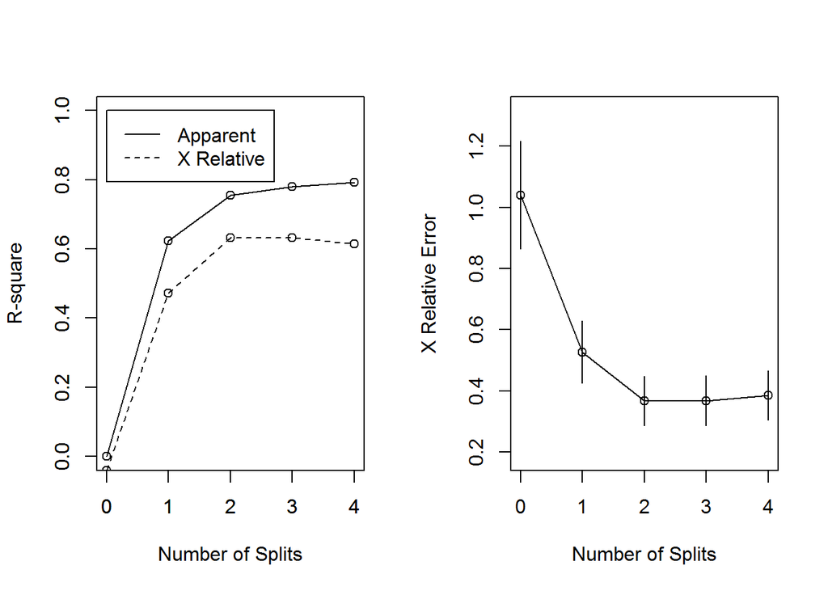

```r
# create additional plots
par(mfrow=c(1,2)) # two plots on one page
rsq.rpart(fit) # visualize cross-validation results
```

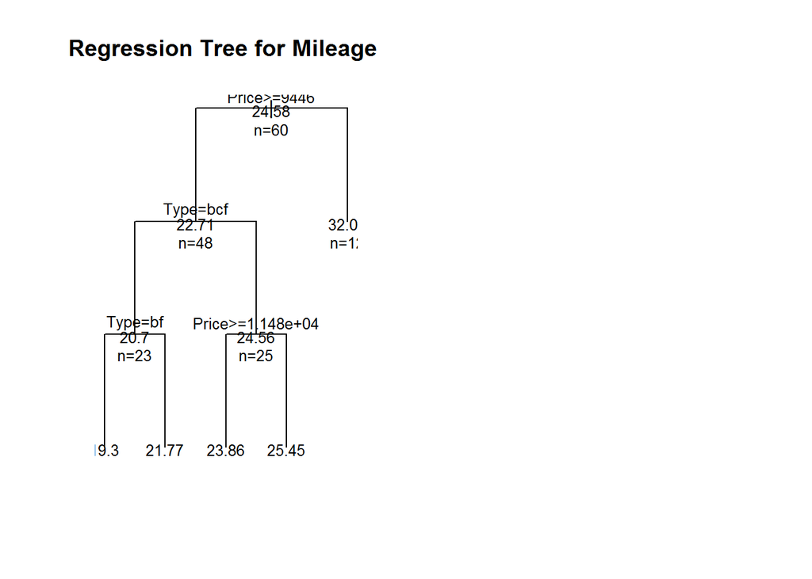

```r
# plot tree
plot(fit, uniform=TRUE,
   main="Regression Tree for Mileage ")
 text(fit, use.n=TRUE, all=TRUE, cex=.8)
```

> **비용-복잡도 가지치기(cost-complexity pruning)**

성장시킨 나무모형 $T_0$를 가지치기하여 얻을 수 있는 나무모형을 $T \subset T_0$로 나타내자. $C_\alpha(T) = \sum_{t \in \tilde T} i(t) + \alpha |T|$ 로 정의되며 가지치기는 $\alpha$에 대하여 $C_\alpha(T)$를 최소화하는 $T_\alpha \subset T_0$를 찾는 문제가 된다.

$|T|$는 $T$에서의 끝마디 개수, 여기서 $\alpha \geq 0$는 나무모형의 크기와 자료에 대한 적합도를 조절하는 조율모수로 $\alpha$값이 크면(작으면) $T_\alpha$의 크기는 작아(커)진다. $\alpha=0$이면 가지치기는 일어나지 않고 $T_0$를 최종모형으로 준다.

추정값 $\hat{\alpha}$은 자료로부터 흔히 5 또는 10-묶음 교차확인오차로 얻을 수 있다. 가지치기된 최종 모형은 $T_{\hat{\alpha}}$으로 나타낼 수 있고 시험자료가 ${x}\in R_m$이면 $\hat{y}=\hat{c}_m$으로 예측한다.

### **분류나무(classification trees)**

출력변수가 범주형인 분류나무는 카이제곱 통계량, 지니지수(Gini index), 엔트로피지수(entropy index) 등을 불순도의 측도로 사용하여 회귀나무와 동일한 방식으로 성장시키게 된다. 오분류율을 불순도의 측도로 사용하여 회귀나무와 동일한 방식으로 실시하여 최종 분류나무모형 $T_{\hat{\alpha}}$을 얻게 된다. 분류나무는 예측값을 각 마디에서 다수결(majority vote) 원칙으로 정함.

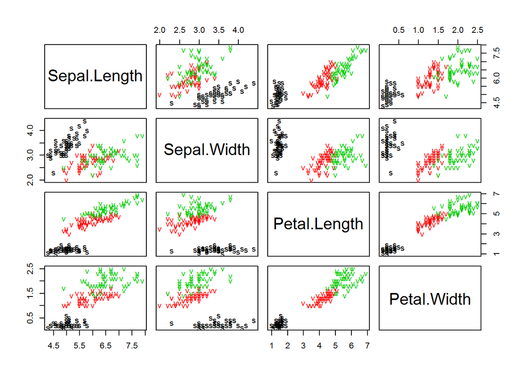

```r
# classfication Tree Example
library(MASS)
library(tree)
data(iris)
plot(iris[,1:4], col=as.integer(iris$Species), pch=substring((iris$Species),1,1))
```

```r
ir.tr = tree(Species ~., iris)
summary(ir.tr)
```

```
##
## Classification tree:
## tree(formula = Species ~ ., data = iris)
## Variables actually used in tree construction:
## [1] "Petal.Length" "Petal.Width"  "Sepal.Length"
## Number of terminal nodes:  6
## Residual mean deviance:  0.1253 = 18.05 / 144
## Misclassification error rate: 0.02667 = 4 / 150
```

```r
ir.tr
```

```
## node), split, n, deviance, yval, (yprob)
##       * denotes terminal node
##
##  1) root 150 329.600 setosa ( 0.33333 0.33333 0.33333 )
##    2) Petal.Length < 2.45 50   0.000 setosa ( 1.00000 0.00000 0.00000 ) *
##    3) Petal.Length > 2.45 100 138.600 versicolor ( 0.00000 0.50000 0.50000 )
##      6) Petal.Width < 1.75 54  33.320 versicolor ( 0.00000 0.90741 0.09259 )
##       12) Petal.Length < 4.95 48   9.721 versicolor ( 0.00000 0.97917 0.02083 )
##         24) Sepal.Length < 5.15 5   5.004 versicolor ( 0.00000 0.80000 0.20000 ) *
##         25) Sepal.Length > 5.15 43   0.000 versicolor ( 0.00000 1.00000 0.00000 ) *
##       13) Petal.Length > 4.95 6   7.638 virginica ( 0.00000 0.33333 0.66667 ) *
##      7) Petal.Width > 1.75 46   9.635 virginica ( 0.00000 0.02174 0.97826 )
##       14) Petal.Length < 4.95 6   5.407 virginica ( 0.00000 0.16667 0.83333 ) *
##       15) Petal.Length > 4.95 40   0.000 virginica ( 0.00000 0.00000 1.00000 ) *
```

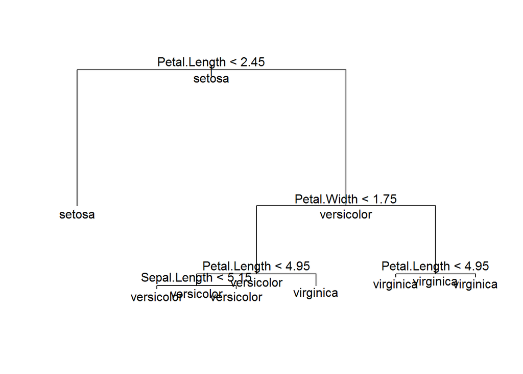

```r
plot(ir.tr)
text(ir.tr, all=T)
```

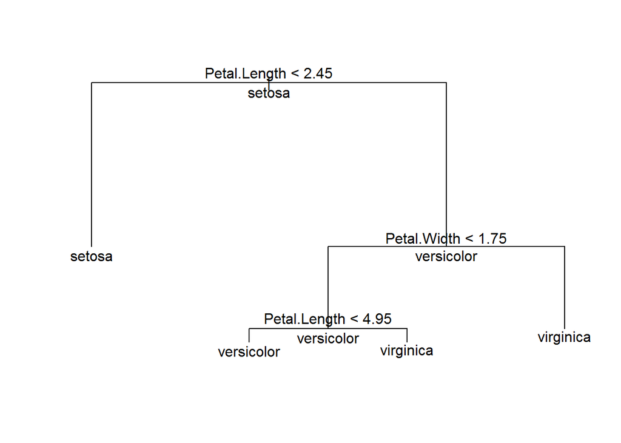

```r
#가지치구 이후 Trees
ir.tr1 = snip.tree(ir.tr, nodes=c(12,7))
plot(ir.tr1)
text(ir.tr1, all=T)
```

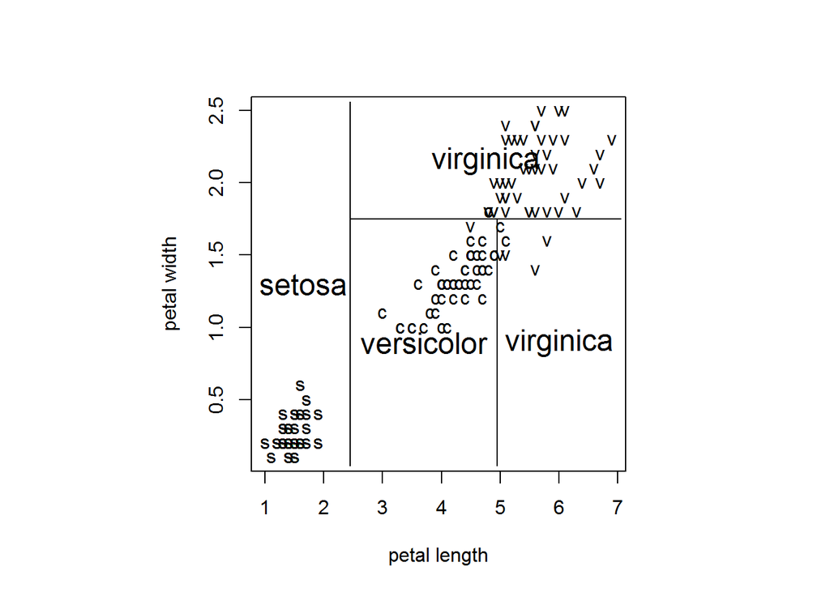

```r
par(pty="s")
plot(iris[,3],iris[,4],type="n", xlab="petal length", ylab="petal width")
text(iris[,3],iris[,4],c("s","c","v")[iris[,5]])
partition.tree(ir.tr1, add=TRUE, cex=1.5)
```

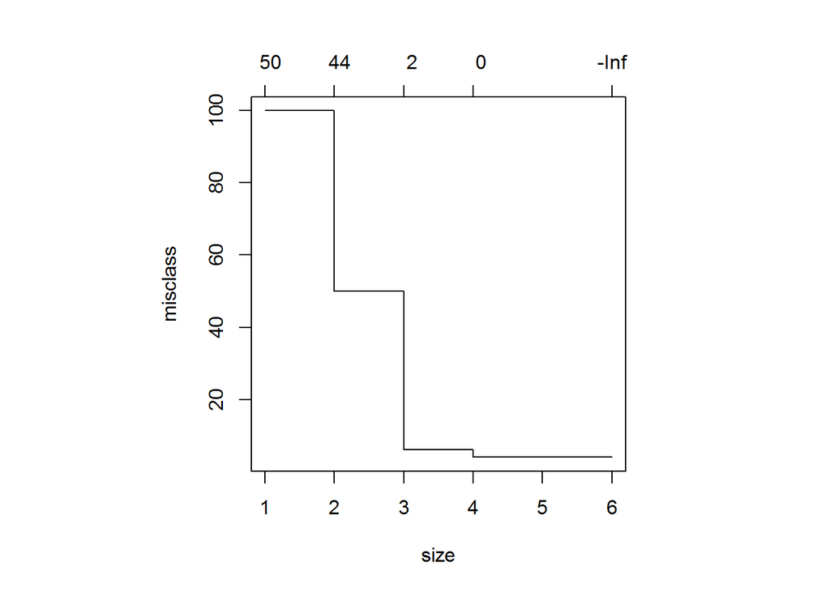

```r
#끝마디의 수를 4로 하여 가지치기
ir.tr2 = prune.misclass(ir.tr)
plot(ir.tr2)
```

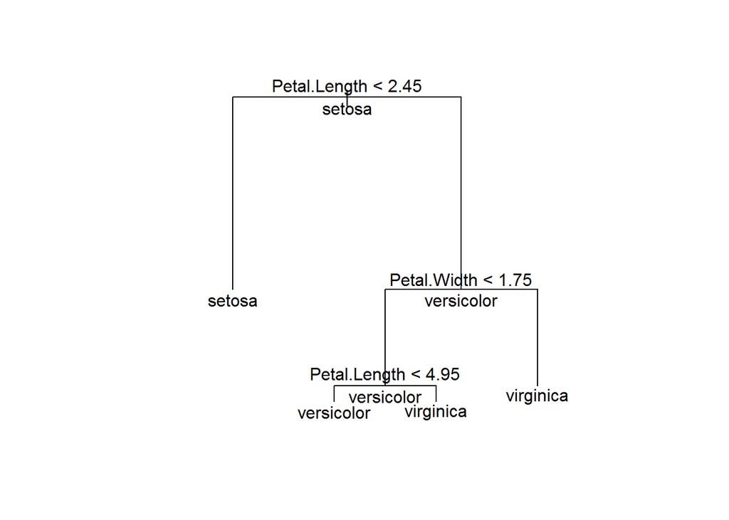

```r
fin.tr = prune.misclass(ir.tr, best=4)
plot(fin.tr)
text(fin.tr, all = T)
```

### **제3절 불순도의 여러가지 측도**

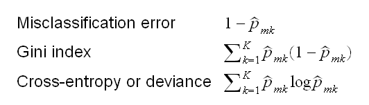

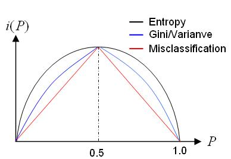

### **제 4절 여러가지 의사결정나무 알고리즘**

> - CART(classfication and regression trees) : Breiman(1984) binary split
> - C4.5와 C5.0 : Quinlan(1993) multiple splilt
> - CHAID : Sonquist(1963)의 AID의 후신

### **제 5절 의사결정나무 특징**

> - 장점
>   - 1. if-then 형식의 이해하기 쉬운 규칙 생성 분류작업 용이
>   - 2. 연속형 변수와 범주형 변수를 모두 취급할 수 있으며 모형에 대한 가정이 필요 없는 비모수적 방법
>   - 3. 설명력 있는 변수에 대하여 최초로 분리 일어나는 특징
> - 단점
>   - 1. 출력변수가 연속형인 회귀모형에서는 예측력이 떨어짐
>   - 2. 복잡한 나무모형은 예측력이 저하되고 해석 어려움 계산량이 많음
>   - 3. 분류경계가 사각형이 아닌 경우 좋지 않은 결과가 줄수 있음
>     4. 자료에 약간의 변화가 있는 경우 전혀 다른 결과를 (분산이 매우 큰) 불안정한 방법 -> 해결책 : 배깅(bagging)